# Data Processing and Visualization of of COVID-19 Outbreak in EU Countries

Peyman Kor

13 Mar 2020

# Package Initialization

Here, we use the the *Coronavirus* package developed and maintained with *Rami Krispin* at this link:

https://github.com/RamiKrispin/coronavirus

In addition, the *Tidyverse* package also was needed to manipulate and visualize the data.

# Data Manipulation

Here, the dplyr was used to select the following countries: + Italy + South Korea + France + Denmark + Norway + Sweden

Then, we calculated the sum of the whole confirmed cases until the given time. In addition, the “row_number” was added to find the days after the Corona Cases has been reached above 25 cases.

```r
eu_cases <- coronavirus %>%
  group_by(Country.Region, date) %>%
  summarise(Cases=sum(cases)) %>%
  filter(Country.Region== "Italy" | Country.Region== "Korea, South" | Country.Region== "France" | Country.Region== "Denmark" |
           Country.Region== "Norway" |
           Country.Region=="Sweden") %>%
  group_by(Country.Region) %>%
  mutate(tot_confirmed = cumsum(Cases)) %>%
  filter(Cases > 25) %>%
  mutate(id = row_number()) %>%
  filter(id < 22)
```

# Mutating Countries Population to the Data

Here, the population of the countries were found and corresponding population was added to the column “pop” in the data set.

```r
populations <- c(81.16, 82.79, 60.48, 51.47, 66.44, 5.6, 5.36, 1386, 67, 10 )
names(populations) <- c("Iran", "Germany", "Italy",  "Korea, South"
                        ,"UK", "Denmark", "Norway" ,"Mainland China", "France", "Sweden")

eu_cases$pop <- rep(0,length(eu_cases$Country.Region))

for (i in 1:length(eu_cases$Country.Region)) {
  country <- as.character(eu_cases$Country.Region[i])
  eu_cases$pop[i] <- populations[[country]]
}
```

# ggplot Theme

Great thanks to Cedric Scherer (cedricphilippscherer@gmail.com) for his beautiful theme!, this theme was used as the theme of the plotting in the bottom

```r
source(here::here("theme", "tidy_grey.R"))
```

```
## Registering fonts with R
```

If you are using the windows, you must install the following the fonts Poppins and Roboto Mono and then:

```r
windowsFonts("Roboto Mono" = windowsFont("Roboto Mono"))
windowsFonts("Poppins" = windowsFont("Poppins"))
```

# Plot Size Modification

Here, we use the custom edit in order to plot the ggplot output in the longer format than the default.

# Visualization:

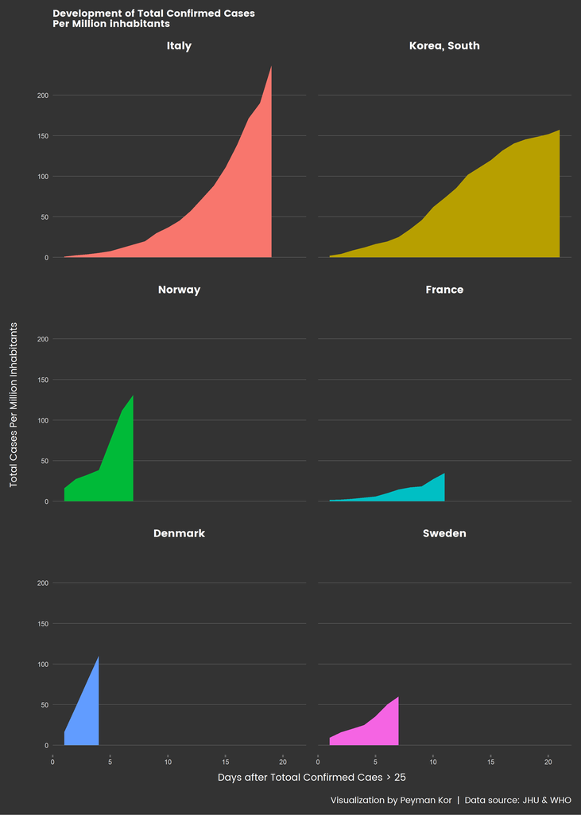

```r
eu_cases <- eu_cases %>% mutate(tot_confirmed_per = tot_confirmed/pop)

eu_cases$Country.Region = factor(eu_cases$Country.Region,
                              levels=c("Italy", "Korea, South","Norway","France" ,"Denmark"
                                        ,"Sweden"))

ggplot(eu_cases, aes(id, tot_confirmed_per, fill = Country.Region)) +
    geom_area() +
    geom_area(alpha = 0.75) +
    facet_wrap(~ Country.Region, nrow = 4) +
    theme(legend.position = "none",
          plot.title = element_text(size=12),
          axis.title = element_text(size = 12, face = "plain"),
          axis.title.x = element_text(size = 12, face = "plain"),
          axis.title.y = element_text(size = 12, face = "plain"),
          axis.text = element_text(family = "Roboto Mono", size = 8.5),
          axis.ticks.x = element_line(colour = "grey40", size = 1),
          axis.ticks.y = element_line(colour = "transparent", size = 0.3),
          panel.grid.major.y = element_line(colour = "grey40", size = 0.3),
          panel.border = element_blank(),
          strip.background = element_rect(color = "transparent"),
          strip.text = element_text(size = 13, colour = "white"),
          panel.spacing = unit(15, "pt")) +
  scale_x_continuous(limits = c(1, 21)) +
    labs(x = "Days after Totoal Confirmed Caes > 25", y = "Total Cases Per Million Inhabitants\n",
         title = "Development of Total Confirmed Cases\nPer Million inhabitants",
         caption = "\nVisualization by Peyman Kor  |  Data source: JHU & WHO")
```